# Exercise 1 — Basic Maps and Graphs in R

BSTA 374 · 12 points · Due Thursday, September 10, 2026, 11:59 pm

Author

Abby Winters · Lehigh University

Published

September 15, 2026

## What this exercise is

Your first graded work in this course. It covers the first two weeks: reading spatial data with `sf`, understanding what a coordinate reference system is and moving between them, and producing honest choropleth and point maps with both `ggplot2` and `tmap`.

**No data to download.** Everything runs on the North Carolina SIDS data that ships inside the `sf` package, so your analysis will reproduce on my machine exactly as it does on yours — which is the point.

Each part ends with **starting code**. Copy it, fill in the blanks marked `______`, and adapt it. It is scaffolding, not a solution: the mechanical lines are given so that your time goes into the parts that require judgement.

**ImportantSubmission**

Submit **one file** to Course Site:

- `LASTNAME_FI_Exercise1.qmd` — the source

Example: `DELMELLE_EM_Exercise1.qmd`. Put your name in the document header.

**Due Thursday, September 10, 2026 at 11:59 pm.** Late work loses 20% per day unless you arrange something with me in advance.

**WarningReproducibility is graded**

Before you submit: restart R (`Ctrl/Cmd + Shift + F10`) and render the document from a clean session. If it does not run start to finish, it is incomplete — regardless of how good the maps are. This is the habit that matters most, and we start enforcing it now.

```r
library(sf)
library(dplyr)
library(ggplot2)
library(tmap)
# add anything else you use -- and load it here, not halfway down

nc <- st_read(system.file("shape/nc.shp", package = "sf"), quiet = TRUE)
```

## Part A — Read and describe the data (2 points)

Answer each in **one or two sentences of prose**, outside the code chunks, and show the code you used to find out.

1. How many features does `nc` contain, and what does one row represent?

   **“nc” contains 100 features and each row is one North Carolina county with its traits attached accordingly. I discovered this by running lines nrow(nc) and names(nc) in the code above.**
2. What geometry type is stored? Why is it that type rather than `POLYGON`? *(Look at the coast.)*

   **Multipolygon is the geometry type stored here. I saw this by running lines nc and table(st_geometry_type(nc)). I believe that it is Multipolygon rather than just polygon because after looking up what the North Carolina Coast looks like, it appears to be very choppy and not just straight land. Therefore, since the area is more choppy and disconnected, it may require more polygons rather than just one.**
3. What coordinate reference system is the data in? Give its name, say whether it is geographic or projected, and say how you found out.

   **The coordinate reference system is NAD27, which is discovered in line st_crs(nc)$input. We can see that it is stored geographic since after running st_crc(nc), it returns coordinates of latitude and longitude.**
4. In your own words, what do `BIR74` and `SID74` measure? Why does having both matter more than having either one alone? **Using “?nc” and following the html link, it states that BIR74 is the “counts of numbers of live births” and SID74 is the “numbers of sudden infant deaths” both for the “July 1, 1974 to June 30, 1978 and July 1, 1979 to June 30, 1984 periods”. I put quotation marks here because I directly quoted this information from the html on the help page. It is very important to have both because it is important that we compare the amount of deaths with the number of births. This will make the analysis more fair because for example if there are a high amount of births, then there will be a high amount of deaths and vice versa. We need to take this into account when analyzing.**

### Starting code

```r
# A1 -- how big is it, and what are the columns?
nrow(nc)
```

```
[1] 100
```

```r
names(nc)
```

```
 [1] "AREA"      "PERIMETER" "CNTY_"     "CNTY_ID"   "NAME"      "FIPS"
 [7] "FIPSNO"    "CRESS_ID"  "BIR74"     "SID74"     "NWBIR74"   "BIR79"
[13] "SID79"     "NWBIR79"   "geometry"
```

```r
nc                       # the header block above the table says a lot
```

```
Simple feature collection with 100 features and 14 fields
Geometry type: MULTIPOLYGON
Dimension:     XY
Bounding box:  xmin: -84.32385 ymin: 33.88199 xmax: -75.45698 ymax: 36.58965
Geodetic CRS:  NAD27
First 10 features:
    AREA PERIMETER CNTY_ CNTY_ID        NAME  FIPS FIPSNO CRESS_ID BIR74 SID74
1  0.114     1.442  1825    1825        Ashe 37009  37009        5  1091     1
2  0.061     1.231  1827    1827   Alleghany 37005  37005        3   487     0
3  0.143     1.630  1828    1828       Surry 37171  37171       86  3188     5
4  0.070     2.968  1831    1831   Currituck 37053  37053       27   508     1
5  0.153     2.206  1832    1832 Northampton 37131  37131       66  1421     9
6  0.097     1.670  1833    1833    Hertford 37091  37091       46  1452     7
7  0.062     1.547  1834    1834      Camden 37029  37029       15   286     0
8  0.091     1.284  1835    1835       Gates 37073  37073       37   420     0
9  0.118     1.421  1836    1836      Warren 37185  37185       93   968     4
10 0.124     1.428  1837    1837      Stokes 37169  37169       85  1612     1
   NWBIR74 BIR79 SID79 NWBIR79                       geometry
1       10  1364     0      19 MULTIPOLYGON (((-81.47276 3...
2       10   542     3      12 MULTIPOLYGON (((-81.23989 3...
3      208  3616     6     260 MULTIPOLYGON (((-80.45634 3...
4      123   830     2     145 MULTIPOLYGON (((-76.00897 3...
5     1066  1606     3    1197 MULTIPOLYGON (((-77.21767 3...
6      954  1838     5    1237 MULTIPOLYGON (((-76.74506 3...
7      115   350     2     139 MULTIPOLYGON (((-76.00897 3...
8      254   594     2     371 MULTIPOLYGON (((-76.56251 3...
9      748  1190     2     844 MULTIPOLYGON (((-78.30876 3...
10     160  2038     5     176 MULTIPOLYGON (((-80.02567 3...
```

```r
# A2 -- one geometry type per feature; count them
table(st_geometry_type(nc))
```

```
          GEOMETRY              POINT         LINESTRING            POLYGON
                 0                  0                  0                  0
        MULTIPOINT    MULTILINESTRING       MULTIPOLYGON GEOMETRYCOLLECTION
                 0                  0                100                  0
    CIRCULARSTRING      COMPOUNDCURVE       CURVEPOLYGON         MULTICURVE
                 0                  0                  0                  0
      MULTISURFACE              CURVE            SURFACE  POLYHEDRALSURFACE
                 0                  0                  0                  0
               TIN           TRIANGLE
                 0                  0
```

```r
# A3 -- three ways of asking about the CRS
st_crs(nc)               # the full definition
```

```
Coordinate Reference System:
  User input: NAD27
  wkt:
GEOGCRS["NAD27",
    DATUM["North American Datum 1927",
        ELLIPSOID["Clarke 1866",6378206.4,294.978698213898,
            LENGTHUNIT["metre",1]]],
    PRIMEM["Greenwich",0,
        ANGLEUNIT["degree",0.0174532925199433]],
    CS[ellipsoidal,2],
        AXIS["latitude",north,
            ORDER[1],
            ANGLEUNIT["degree",0.0174532925199433]],
        AXIS["longitude",east,
            ORDER[2],
            ANGLEUNIT["degree",0.0174532925199433]],
    ID["EPSG",4267]]
```

```r
st_crs(nc)$input         # the short name
```

```
[1] "NAD27"
```

```r
st_is_longlat(nc)        # TRUE = geographic (degrees), FALSE = projected (metres)
```

```
[1] TRUE
```

```r
# A4 -- the help page documents every column
?nc
```

## Part B — Coordinate reference systems (2 points)

1. Transform `nc` to **EPSG:32119** (NAD83 / North Carolina State Plane, in metres) and store it as a **new object**. Do not overwrite `nc` — you need both.

   **Done in #B1 line: nc_proj <- st_transform(nc, 32119)**
2. Plot the counties **before and after**, near enough to each other that a reader can compare them. One or two sentences on what visibly changed.

   **This was done under #B2. The shape appears to remain the same overall shape from map to map, yet the 2nd map is slightly more bent upwards and stretched visibly.**
3. Compute the area of every county in **square kilometres**, using the projected version. Report the five largest.

   **The 5 largest are Columbus (2450.349 km), Robeson (2439.238 km), Sampson (2437.410 km), Bladen (2288.424) km, and Wake (2194.261 km).**
4. Now compute areas from the *unprojected* object as well. Compare the two sets of numbers and explain, in two or three sentences, what `sf` did and why the projected version is the one you would report in a paper.

   **The numbers calculated here are very, very slightly off than the projected values. They are only about a few decimal values higher. “Sf” uses the curved surface of the Earth when calculating areas from the unprojected data. On the other hand, the projected data uses coordinates in meters on a flat map. The projected values should be reported since the projected areas are intended to be more accurate in measurement for distance and area.**

**Note**

Step 4 will not give you an error, and the two sets of numbers will be close but not identical. That is the interesting part — the question is which *surface* each answer refers to.

### Starting code

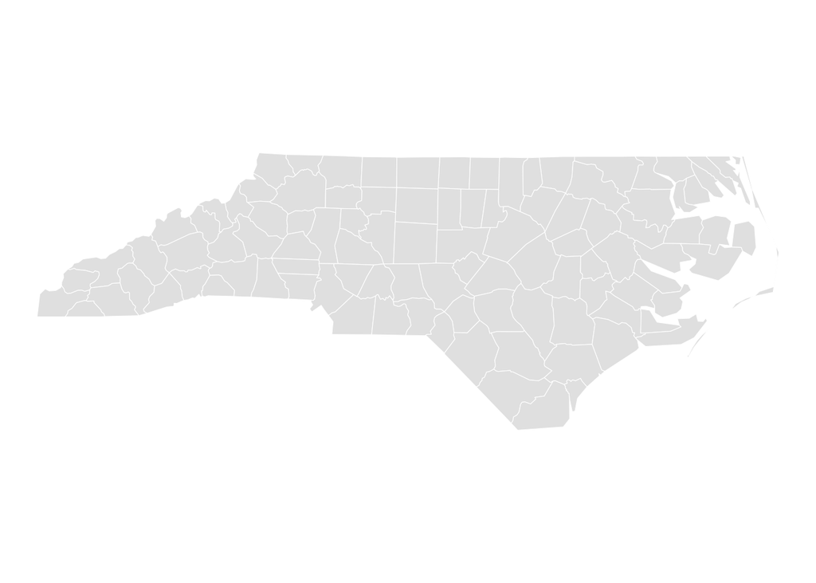

```r
# B1
nc_proj <- st_transform(nc, 32119)

# B2 -- one plot each
p1 <- ggplot(nc)      + geom_sf(fill = "grey90", colour = "white") + theme_void()
p2 <- ggplot(nc_proj) + geom_sf(fill = "grey90", colour = "white") + theme_void()

p1
```

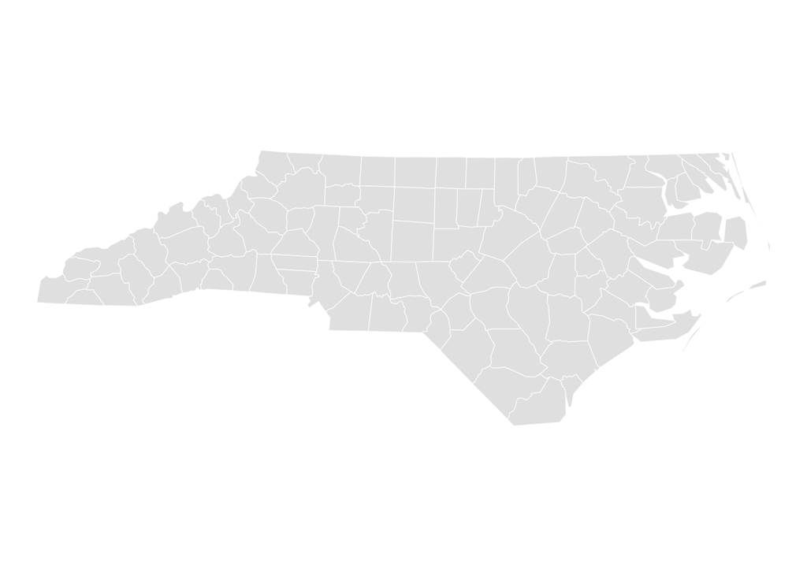

```r
p2
```

```r
# side by side, if you like:  library(patchwork);  p1 + p2

# B3 -- st_area() returns square METRES, as a units object
nc_proj <- nc_proj |>
  mutate(area_km2 = as.numeric(units::set_units(st_area(nc_proj), km^2)))

nc_proj |>
  st_drop_geometry() |>
  slice_max(area_km2, n = 5) |>
  select(NAME, area_km2)
```

```
      NAME area_km2
1 Columbus 2450.349
2  Robeson 2439.238
3  Sampson 2437.410
4   Bladen 2288.424
5     Wake 2194.261
```

```r
# B4 -- now do the same starting from nc (degrees) and compare
nc_unproj <- nc # Created a new variable to make it more clear that this is for the unprojected data
nc_unproj <- nc |>
  mutate(area_km2 = as.numeric(units::set_units(st_area(nc), km^2)))

nc_unproj |>
  st_drop_geometry() |>
  slice_max(area_km2, n = 5) |>
  select(NAME, area_km2)
```

```
      NAME area_km2
1 Columbus 2450.831
2  Robeson 2439.935
3  Sampson 2438.121
4   Bladen 2289.053
5     Wake 2194.374
```

```r
# Same code structure as B3 but accounting for change in data
```

## Part C — Choropleth maps (5 points)

This is the largest part of the exercise, and it is as much about judgement as about code.

1. Add a column giving the **SIDS rate per 1,000 live births** for 1974–78.
2. Make a choropleth of the **raw counts** (`SID74`) and one of the **rate**, using `ggplot2`. Then write three or four sentences explaining why the two maps disagree, and which one you would put in front of a health department, and why.

   **The maps are different because one shows that the total number of sudden infant deaths and the other shows the rate of SIDS per 1,000 births. I would chose the rate map to show in front of a health department because it puts the data into a more accurate comparison. For example, a county with more births will have more deaths, so the rate map shows more accurate information since it is scaled accurately with this comparative data. It helps account for differences in population size and therefore, shows the level of risk better.**
3. Rebuild the rate map using **`tmap`**. Same information, other package.
4. Vary the **class intervals** on the rate map: produce it at least three ways — for instance equal intervals, quantiles, and Jenks natural breaks. Two or three sentences on how much the apparent geography of risk changes. Name the classification you would defend, and say why.

   **I choose viridis since it is a color-blind-safe palette and it makes the maps easier to read. Darker colors mean higher SID rates and lighter colors mean lower SID rates.**

**TipWhat earns full marks here**

Not the prettiest map — the map whose choices you can defend. A student who picks quantiles and explains the trade-off in two clear sentences scores higher than one who picks Jenks because it looked nicer.

### Starting code

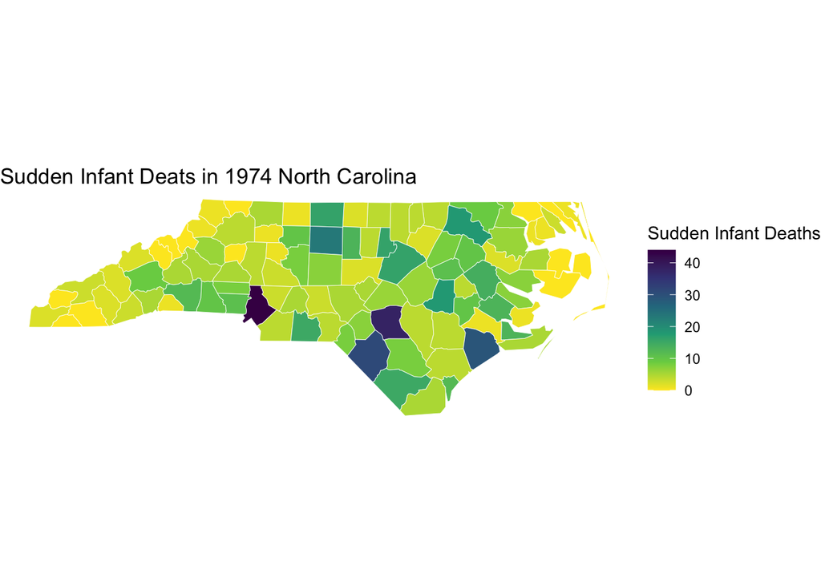

```r
# C1 -- deaths per 1,000 live births
nc <- nc |>
  mutate(rate74 = (SID74 / BIR74) * 1000)

# C2 -- counts, then rates. Same code, one variable changed.
ggplot(nc) +
  geom_sf(aes(fill = SID74), colour = "white", linewidth = 0.15) +
  scale_fill_viridis_c(option = "viridis", direction = -1, name = "Sudden Infant Deaths") +
  labs(title = "Sudden Infant Deats in 1974 North Carolina") +
  theme_void()
```

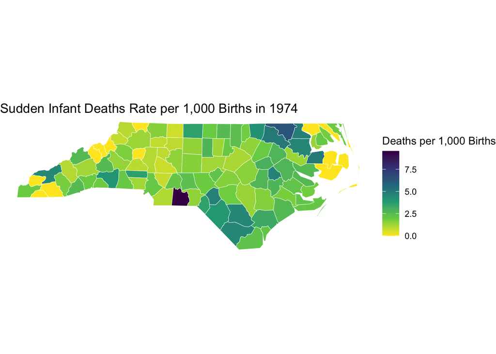

```r
ggplot(nc) +
  geom_sf(aes(fill = rate74), colour = "white", linewidth = 0.15) +
  scale_fill_viridis_c(option = "viridis", direction = -1, name = "Deaths per 1,000 Births") +
  labs(title = "Sudden Infant Deaths Rate per 1,000 Births in 1974") +
  theme_void()
```

```r
# other palettes to try:
#   scale_fill_viridis_c(option = "viridis" / "plasma" / "cividis" / "mako")
#   scale_fill_distiller(palette = "YlOrRd", direction = 1)
#   RColorBrewer::display.brewer.all()   # shows every ColorBrewer option

# C3 -- the same map in tmap
tmap_mode("plot")                        # "view" makes it interactive
```

```
ℹ tmap modes "plot" - "view"
ℹ toggle with `tmap::ttm()`
```

```
── tmap v3 code detected ───────────────────────────────────────────────────────
[v3->v4] `tm_tm_polygons()`: migrate the argument(s) related to the scale of
the visual variable `fill` namely 'palette' (rename to 'values') to fill.scale
= tm_scale(<HERE>).
```

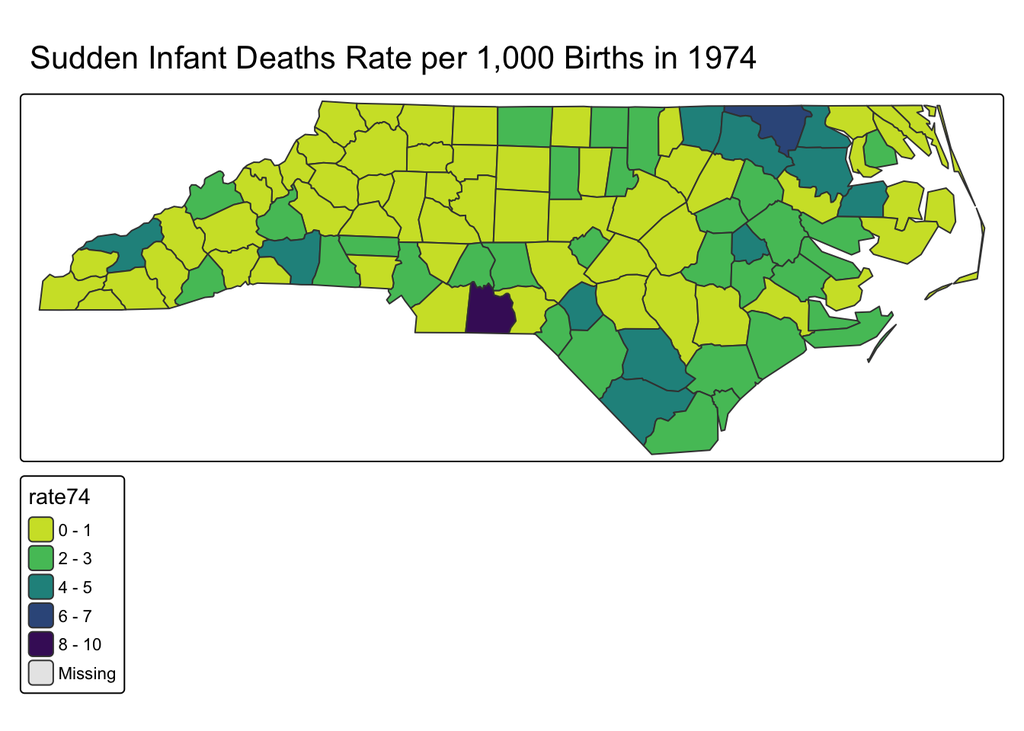

```r
tm_shape(nc) +
  tm_polygons(fill = "rate74", palette = "-viridis") +
  tm_title("Sudden Infant Deaths Rate per 1,000 Births in 1974")
```

```
── tmap v3 code detected ───────────────────────────────────────────────────────
[v3->v4] `tm_tm_polygons()`: migrate the argument(s) related to the scale of
the visual variable `fill` namely 'palette' (rename to 'values') to fill.scale
= tm_scale(<HERE>).
```

[figure not shown]

```r
# C4 -- change ONLY the classification, so the comparison is fair
tm_shape(nc) +
  tm_polygons(fill = "rate74", palette = "-viridis",
              fill.scale = tm_scale_intervals(style = "quantile", n = 5)) +
  tm_title("Quantiles")
```

```
── tmap v3 code detected ───────────────────────────────────────────────────────
[v3->v4] `tm_tm_polygons()`: migrate the argument(s) related to the scale of
the visual variable `fill` namely 'palette' (rename to 'values') to fill.scale
= tm_scale(<HERE>).
```

[figure not shown]

```r
tm_shape(nc) +
  tm_polygons(fill = "rate74", palette = "-viridis",
              fill.scale = tm_scale_intervals(style = "equal", n = 5)) +
  tm_title("Equal Intervals")
```

```
── tmap v3 code detected ───────────────────────────────────────────────────────
[v3->v4] `tm_tm_polygons()`: migrate the argument(s) related to the scale of
the visual variable `fill` namely 'palette' (rename to 'values') to fill.scale
= tm_scale(<HERE>).
```

[figure not shown]

```r
tm_shape(nc) +
  tm_polygons(fill = "rate74", palette = "-viridis",
              fill.scale = tm_scale_intervals(style = "jenks", n = 5)) +
  tm_title("Jenks Natural Breaks")
```

```r
# then repeat with style = "equal" and style = "jenks"
# other options: "pretty", "fisher"
```

**WarningA note on `tmap` versions**

`tmap` changed its argument names in version 4. If an example you find online uses `tm_polygons(col = ...)` or `style = ...` directly and yours errors, check `packageVersion("tmap")` and read the help page rather than guessing. The code above is written for version 4.

## Part D — A point layer (2 points)

1. Look up the approximate longitude and latitude of **four cities in North Carolina** and build a small table holding the name and the two coordinates. Cite where you got the coordinates.

   **I got my coordinates from this website: https://time-ok.com/coordinates/north-carolina**
2. Turn that table into an `sf` object with the correct CRS. State which EPSG code you used and why.

   **I used EPSG 4326 because the longitudes and latitudes are in decimal form.**
3. Plot the four cities **on top of** your rate choropleth, labelled legibly.
4. One sentence: what would go wrong if you built the `sf` object with the coordinate columns in the other order?

   **If the longitutude and latitude were reveresed, the points would be in the incorrect locations.**

### Starting code

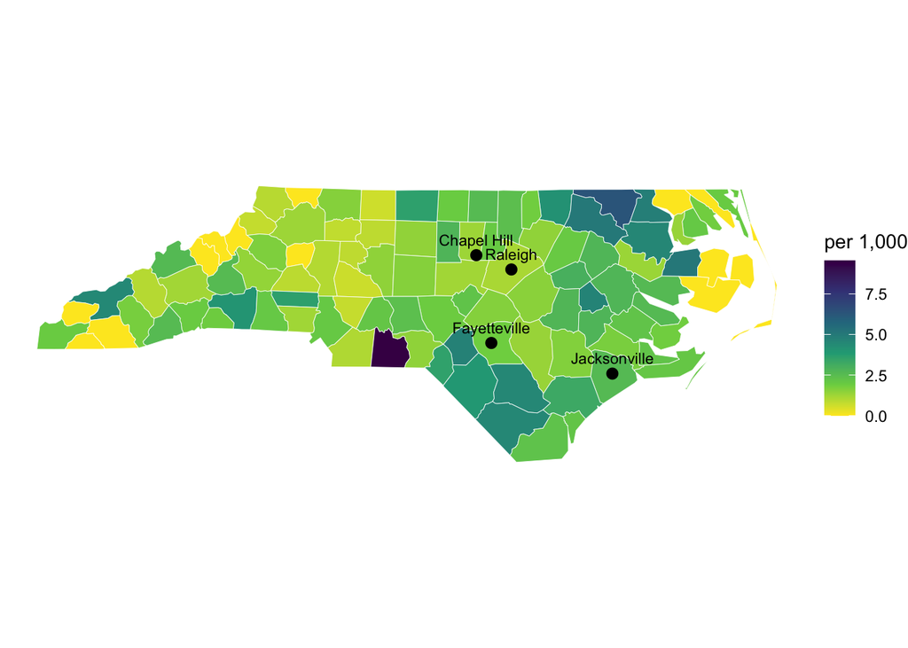

```r
# D1 -- North Carolina longitudes are NEGATIVE (west of Greenwich)
cities <- tibble(
  name = c("Raleigh", "Fayetteville", "Chapel Hill", "Jacksonville"),
  lon  = c(-78.64, -78.88, -79.06, -77.43),
  lat  = c(35.77, 35.05, 35.91, 34.75)
)

# D2 -- coords takes the column names in x, y order: longitude FIRST
cities_sf <- cities |>
  st_as_sf(coords = c("lon", "lat"), crs = 4326)

# D3 -- layers draw in order, so points come after polygons
ggplot() +
  geom_sf(data = nc, aes(fill = rate74), colour = "white", linewidth = 0.15) +
  geom_sf(data = cities_sf, size = 2.5, colour = "black") +
  geom_sf_text(data = cities_sf, aes(label = name), size = 3, nudge_y = 0.15) +
  scale_fill_viridis_c(option = "viridis", direction = -1, name = "per 1,000") +
  theme_void()
```

```r
# check your cities landed in North Carolina and not in the ocean
```

## Part E — Reproducibility and AI use (1 point)

1. Your document renders from a clean session, with every package loaded explicitly. *(Check this last, after you have stopped editing.)*
2. End the document with an **AI use note**: which tools you used, what for, and at which stage — planning, coding, debugging, interpreting, or writing. Two or three sentences.

Remember the course policy: AI use is unrestricted and costs you nothing, but you must be able to explain every line you hand in. Disclosure is the only requirement.

**Disclosure: I used AI to help with B4. I did the code part myself, yet it was unclear to me what “sf” was used for. It helped me understand what that function was in order to be able to answer the question. I used AI again because I kept getting an error with the tmap package and it wouldn’t allow me to run the later maps without it. AI suggested that I need to fully install it in my console and this helped me debug the issue. I used AI for C5 because I wasn’t sure how to set the palette to viridis for the C3 and C4 maps. AI suggested I insert palette = “viridis” to change the palettes within the code lines. I then noticed my higher and lighter colors were reversed on my maps and I wanted them to all be uniform so AI suggested I use palette = “-viridis” to correct this.**

## Rubric

| Part | What is assessed | Points |
| --- | --- | --- |
| **A** | Correct inspection of the object; clear, accurate answers | 2 |
| **B** | Correct transformation and areas; comparison explained | 2 |
| **C** | Both packages working; counts-vs-rates argument; class intervals compared and a defended choice; cartographic standards met | 5 |
| **D** | Point layer built with the right CRS and correctly overlaid | 2 |
| **E** | Renders from a clean session; AI use note present | 1 |
|  | **Total** | **12** |

Writing counts for roughly 10% of the mark within each part: the prose should be in complete sentences and free of obvious errors. Every part asks for interpretation as well as code — a submission that is all code and no sentences cannot score above about 60%.

## Getting help

- Office hours, or email me — with the code and the exact error message, not a screenshot of the whole console.
- The `sf` documentation is genuinely good: `vignette("sf1", package = "sf")`.
- Moraga Chapter 2 covers most of Parts A–C.
- If you are stuck for more than about thirty minutes on something that feels mechanical, that is a signal to ask rather than to persevere.